# DLNM Sturgeon Model

# TL;DR

# Load and maniuplate data

```r
# Load packages
library(parallel); library(dlnm); library(mgcv); library(data.table)
# Load file, dropping row names
sturg <- fread("sturgoSSTlags.csv", drop = 1, col.names = tolower)


# Reclass predictors, take log of CHL-A
sturg <- sturg[, ':='(day = as.POSIXct(day, format = "%Y-%m-%d"),
                      site = as.factor(site),
                      year = as.factor(year),
                      chla = log(chla))]


# Sum sturgeon presence for each combination of predictors and remove any with
#   missing observations.
sturg_agg <- sturg[, .(freq = sum(freq, na.rm = T)),
                   by = c('site', 'day', 'doy', 'chla', 'sst', 'depth',
                          'd50.s', 'time', 'season', 'seasonb', 'year')]
sturg_agg <- na.omit(sturg_agg)


# Pull out SST lags from original data to join with aggregated presence
sst_lags <- subset(sturg, select = grep('site|day|sst.', names(sturg), value = T))


# Join sturgeon presence and lags
sturg <- sturg_agg[sst_lags, on = c('day', 'site'), nomatch = 0]
sturg <- unique(sturg)

sturg
```

```
##        site        day doy      chla    sst depth    d50.s time        season
##     1:  AM1 2016-11-15 320 1.1818800 14.821  19.2 618.4936    1 Autumn/Winter
##     2:  AM3 2016-11-15 320 0.8955980 15.236  25.0 608.3227    1 Autumn/Winter
##     3:  AM4 2016-11-15 320 0.6546952 15.443  26.2 611.1025    1 Autumn/Winter
##     4:  AN1 2016-11-15 320 1.2161404 14.835  16.2 583.9415    1 Autumn/Winter
##     5:  AN2 2016-11-15 320 0.9708312 15.066  25.0 618.5662    1 Autumn/Winter
##    ---
## 13680:  IS2 2018-12-04 338 1.2372049 10.046  15.8 510.8032  750 Autumn/Winter
## 13681:  ON1 2018-12-04 338 0.7298440 11.573  36.0 526.3346  750 Autumn/Winter
## 13682:  ON2 2018-12-04 338 0.6001944 11.963  36.0 587.4913  750 Autumn/Winter
## 13683:  OS1 2018-12-04 338 0.7210828 11.738  35.4 547.4926  750 Autumn/Winter
## 13684:  OS2 2018-12-04 338 0.6611409 12.010  40.2 546.2760  750 Autumn/Winter
##        seasonb year freq   sst1   sst2   sst3   sst4   sst5   sst6   sst7
##     1:  Autumn   17    0     NA     NA     NA     NA     NA     NA     NA
##     2:  Autumn   17    0     NA     NA     NA     NA     NA     NA     NA
```

[output cut: 45 more lines]

# Model fitting

When a model is fit using `mgcv::gam`, the input data is usually in a data frame. Here, however, we are putting each predictor into the element of a list rather than a column of a data frame. This is because we need a matrix of values to calculate the lagged smooth. See [Gasparrini et al. 2017](http://www.ag-myresearch.com/2017_gasparrini_biomet.html) and the [associated code](https://github.com/gasparrini/2017_gasparrini_Biomet_Rcodedata) for fitting the smooth, and [`?mgcv::linear.functional.terms`](https://www.rdocumentation.org/packages/mgcv/versions/1.8-31/topics/linear.functional.terms) for the math-ier `mgcv` stuff.

```r
# Convert data from data.frame to list
sturg_list <- as.list(sturg)


# Set up SST lag matrix, and assign to an element of the list
sturg_list[['sst_lag_matrix']] <-
  as.matrix(
    subset(sturg, select = grep('sst.', names(sturg), value = T))
  )

# Define lags, and assign to an element of the list
sturg_list[['lag_num_matrix']] <-
  matrix(0:(ncol(sturg_list$sst_lag_matrix) - 1),
         nrow(sturg_list$sst_lag_matrix),
         ncol(sturg_list$sst_lag_matrix),
         byrow = TRUE)
```

Following previous model selection, we know that the best model is fit with the following code.

```r
model <- gam(freq ~
               s(sst_lag_matrix, lag_num_matrix, bs = 'cb', k = 10) +
               s(site, bs = 're') +
               s(year, bs = 're') +
               s(chla, bs = 'tp') +
               t2(doy, depth, bs = c('cp', 'tp'), k = 6) +
               offset(log(d50.s)),
             data = sturg_list,
             family = ziP,
             method = 'REML')
```

However, this takes a while to run, so I’m just going to load a saved version.

```r
model <- readRDS('sturgeon_mod_SM6.rds')
summary(model)
```

```
##
## Family: Zero inflated Poisson(-0.459,0.944)
## Link function: identity
##
## Formula:
## freq ~ s(sst_lag_matrix, lag_num_matrix, bs = "cb", k = 10) +
##     s(site, bs = "re") + s(year, bs = "re") + s(chla, bs = "tp") +
##     t2(doy, depth, bs = c("cp", "tp"), k = 6) + offset(log(d50.s))
##
## Parametric coefficients:
##             Estimate Std. Error z value Pr(>|z|)
## (Intercept)   -7.729      0.251  -30.79   <2e-16 ***
## ---
## Signif. codes:  0 '***' 0.001 '**' 0.01 '*' 0.05 '.' 0.1 ' ' 1
##
## Approximate significance of smooth terms:
##                                     edf Ref.df Chi.sq  p-value
## s(sst_lag_matrix,lag_num_matrix) 20.138 24.433  82.15 3.17e-08 ***
## s(site)                          13.296 20.000 223.42  1.00000
## s(year)                           1.841  3.000 243.16  0.34917
## s(chla)                           5.717  6.813  22.81  0.00155 **
## t2(doy,depth)                    19.969 22.291 214.19  < 2e-16 ***
## ---
## Signif. codes:  0 '***' 0.001 '**' 0.01 '*' 0.05 '.' 0.1 ' ' 1
##
## Deviance explained = 82.2%
## -REML = 2544.9  Scale est. = 1         n = 13114
```

# 5-fold cross validation

This takes a long time, so only showing the code. Will load a pre-saved version afterward.

```r
set.seed(8675309)

# Shuffle data prior to divvying into folds
sturg_shuffle <- sturg[sample(nrow(sturg))]


# Create 5 equally-sized folds
folds <- cut(seq(1, nrow(sturg_shuffle)),
             breaks = 5, labels = FALSE)



# Create model-fitting function to run in parallel
fold_fit <- function(i){
  test_indices <- which(folds == i, arr.ind = TRUE)
  test_data <- sturg_shuffle[test_indices, ]
  train_data <- sturg_shuffle[-test_indices, ]


  create_input_data <- function(model_data){
    sturg_list <- as.list(model_data)

    # Set up SST lag matrix, and assign to an element of the list
    sturg_list[['sst_lag_matrix']] <-
      as.matrix(
        subset(model_data, select = grep('sst.', names(model_data), value = T))
      )

    # Define lags, and assign to an element of the list
    sturg_list[['lag_num_matrix']] <-
      matrix(0:(ncol(sturg_list$sst_lag_matrix) - 1),
             nrow(sturg_list$sst_lag_matrix),
             ncol(sturg_list$sst_lag_matrix),
             byrow = TRUE)

    sturg_list
  }


  # Train the model
  train_data <- create_input_data(train_data)

  cv_mod <- gam(freq ~
                  s(sst_lag_matrix, lag_num_matrix, bs = 'cb', k = 10) +
                  s(site, bs = 're') +
                  s(year, bs = 're') +
                  s(chla, bs = 'tp') +
                  t2(doy, depth, bs = c('cp', 'tp'), k = 6) +
                  offset(log(d50.s)),
                data = train_data,
                family = ziP,
                method = 'REML')


  # Test the model, assign fitted values to test_data
  test_data <- create_input_data(test_data)

  test_data$fit <- predict(cv_mod, test_data, type = "response")


  # Export
  list(cv_mod = cv_mod,
       data = test_data)
}



# Create cluster to run models in parallel
parallel_cluster <- makeCluster(detectCores() - 1)

# Load packages in cluster
clusterEvalQ(cl = parallel_cluster,
             c(library(dlnm), library(mgcv), library(data.table)))

# Export data to the cluster
clusterExport(cl = parallel_cluster,
              c('sturg_shuffle', 'folds'))



# Perform 5-fold cross validation in parallel
cv_results <- parLapply(1:5, fold_fit, cl = parallel_cluster)



# Close cluster
stopCluster(cl)
```

## Cross validation metrics

Load the above (previously-run and saved).

```r
cv_results <- readRDS('CV_sturgeon_mod_SM6.rds')

rmse <- sapply(cv_results, function(.) sqrt(mean((.$data$freq - .$data$fit) ^ 2, na.rm = T)))
rmse
```

```
## [1] 0.2794267 0.3282127 0.2755002 0.2478875 0.3142489
```

```r
mean(rmse)
```

```
## [1] 0.2890552
```

```r
sd(rmse)
```

```
## [1] 0.03216854
```

## Quick partial effects plots

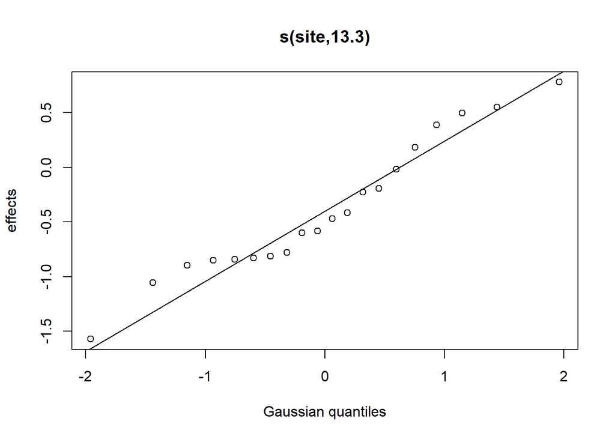

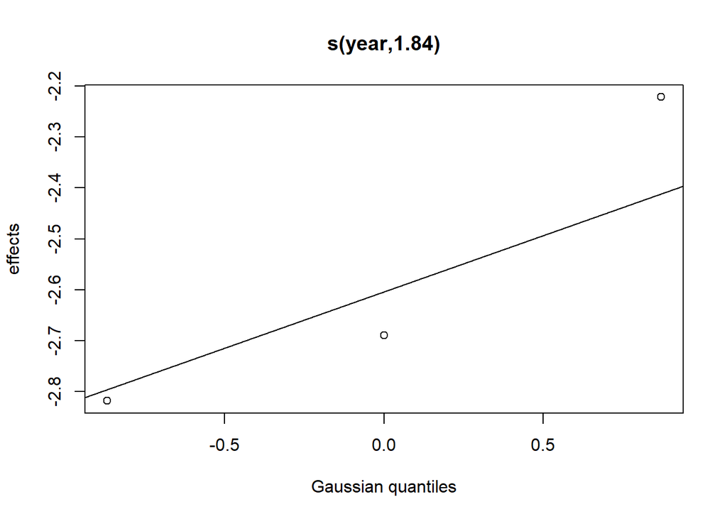

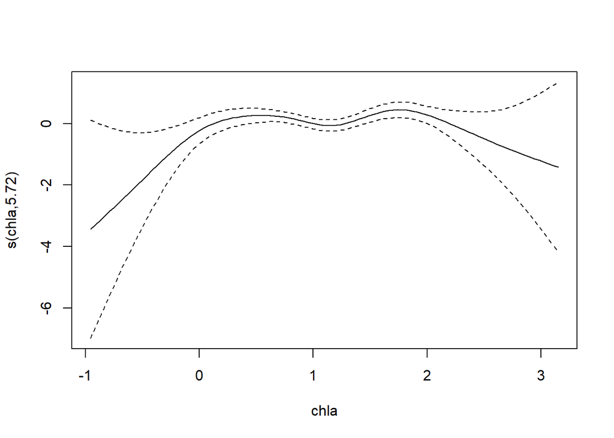

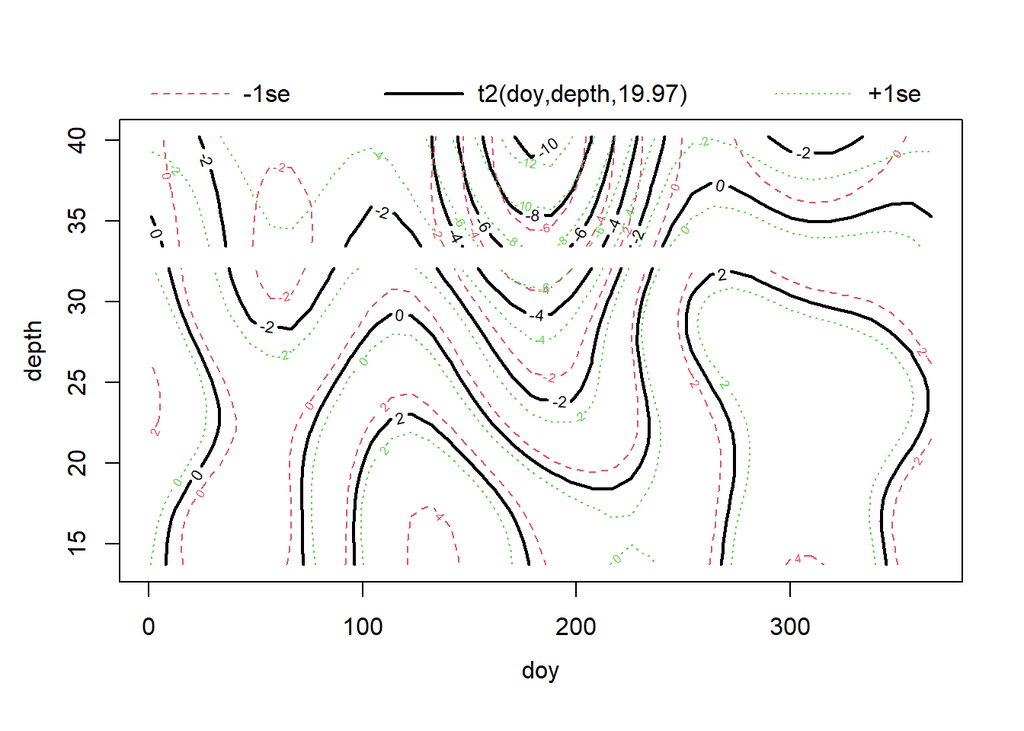

```r
plot(model)
```

And a quick view of the lag smooth.

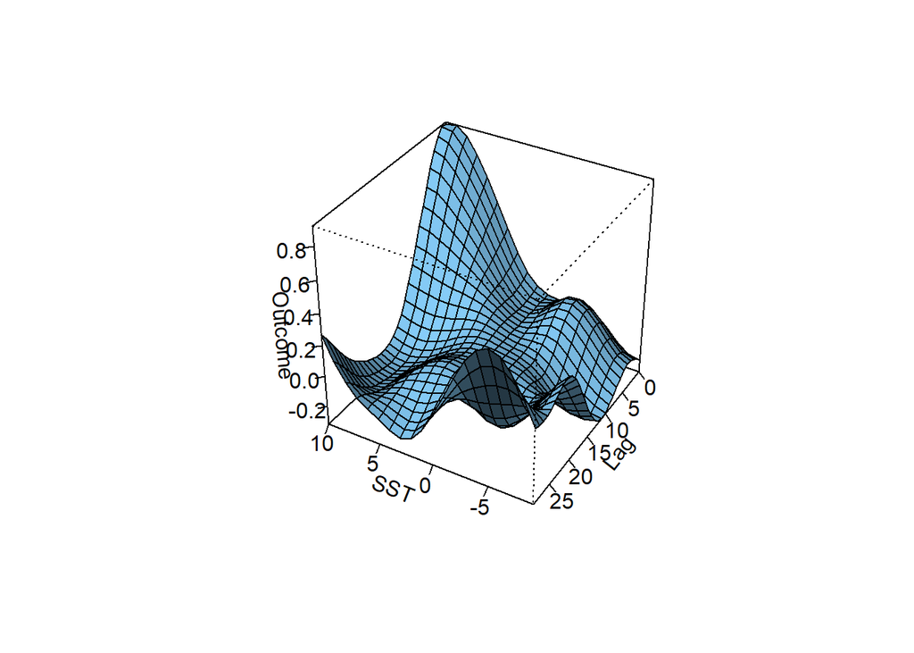

```r
lag_preds <- crosspred('sst_lag_matrix', model, by = 1, cen = 0)

plot(lag_preds, xlab = 'SST', ylab = 'Lag', ltheta = 170, phi = 35, lphi = 30)
```

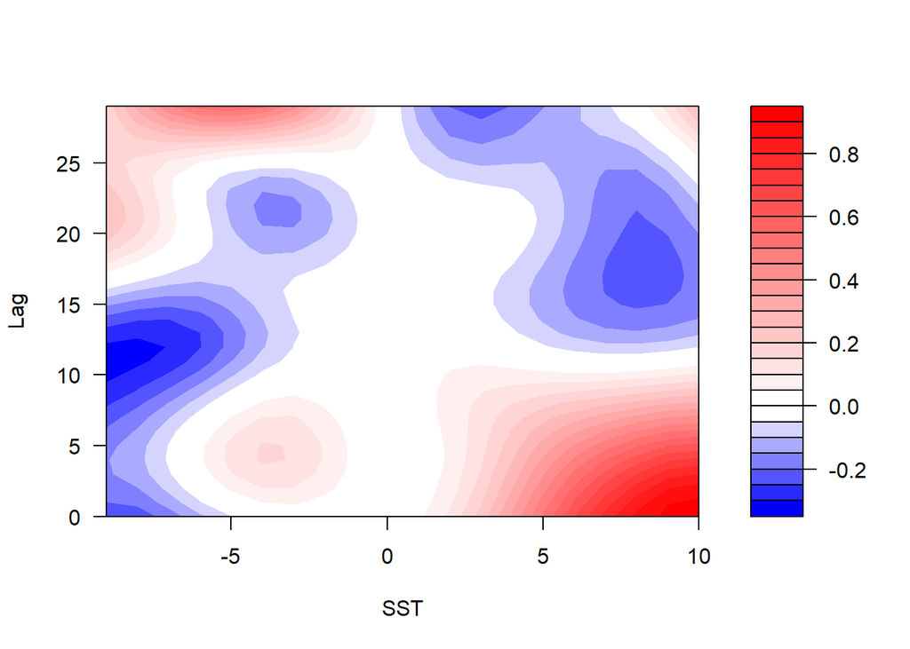

```r
plot(lag_preds, 'contour', xlab = 'SST', ylab = 'Lag')
```

# Lag smooth

The canned function for the partial effect of the lag smoother provides the “estimated associations defined on a grid of values of the original predictor and lags, **computed versus a reference predictor value**. Here, SST is centered, so the reference value is mean SST. Since the partial effect is computed versus this”reference predictor value", we are forcing 0°C SST to intersect with 0 effect on sturgeon presence. So, we are assuming that there is no effect of lagged temperature on sturgeon frequency when the lagged temperature equals 0°C (no difference in temperature between then and now). Below are partial effects plots, taking slices across SST for each lag. Standard errors are shown in the envelope.

Note that negative SST means it was warmer however many lags ago, positive SST means it was cooler however many lags ago.

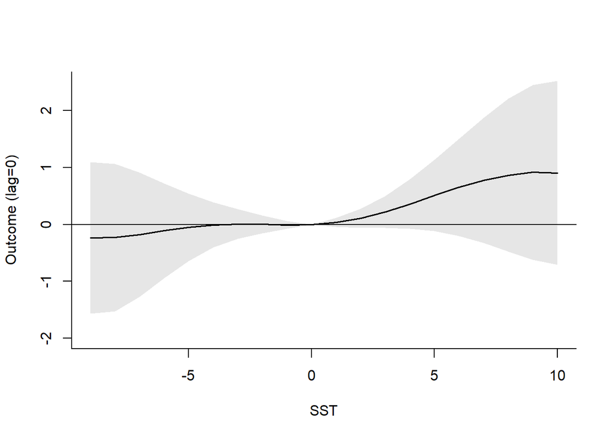

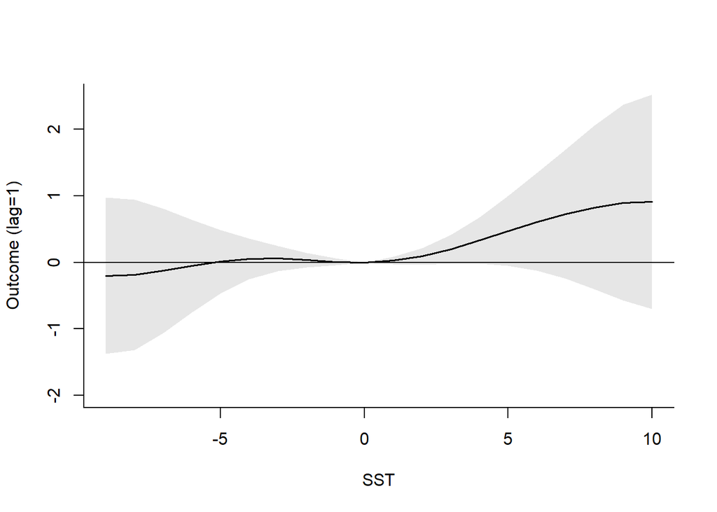

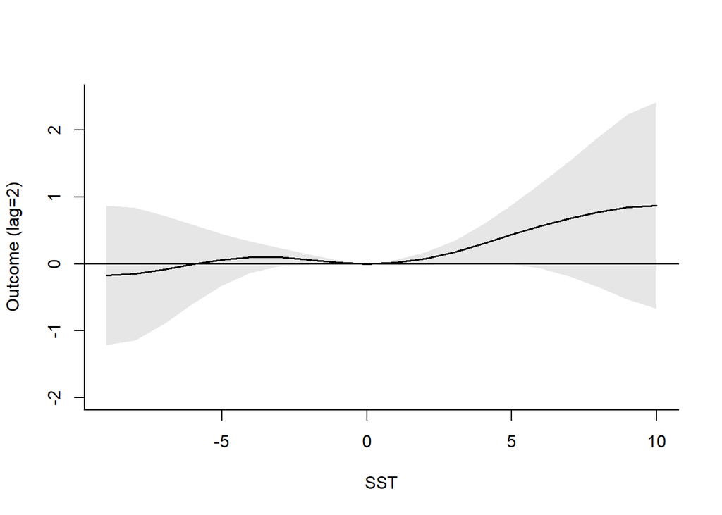

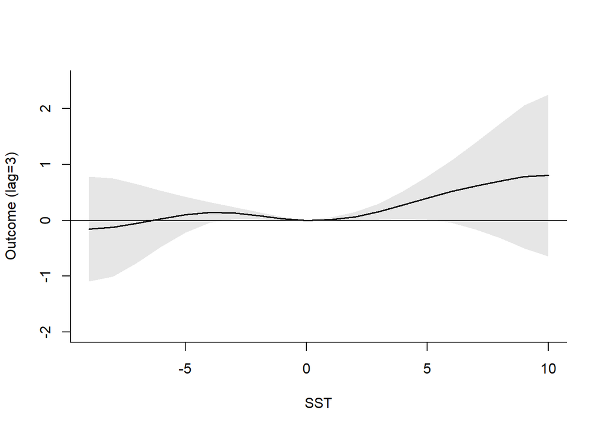

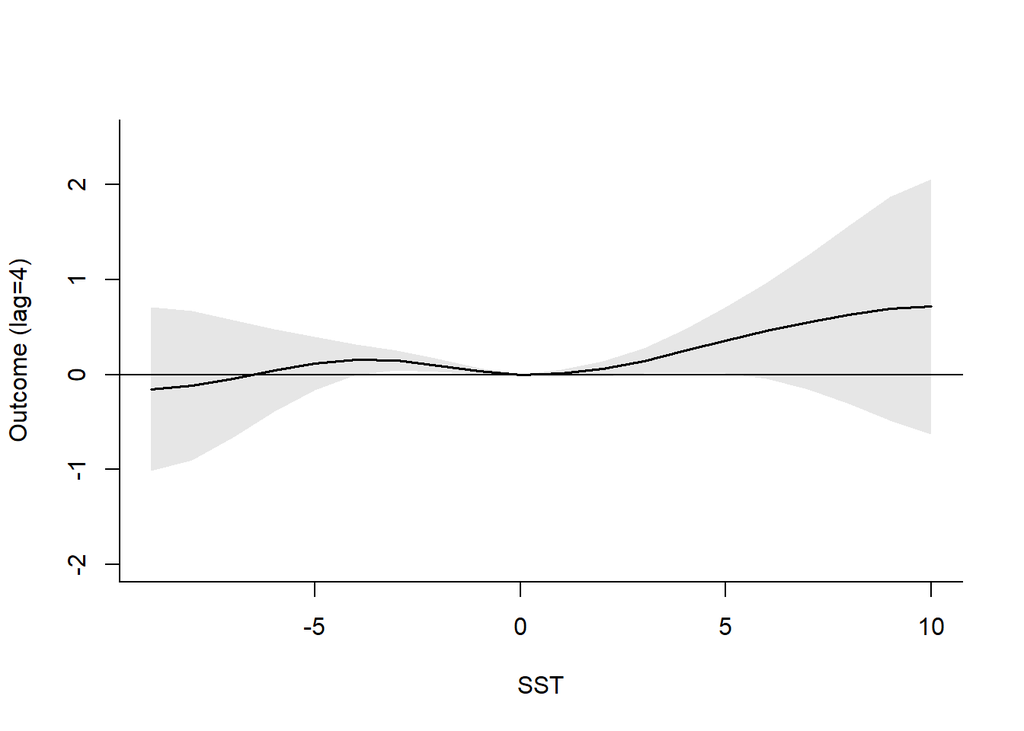

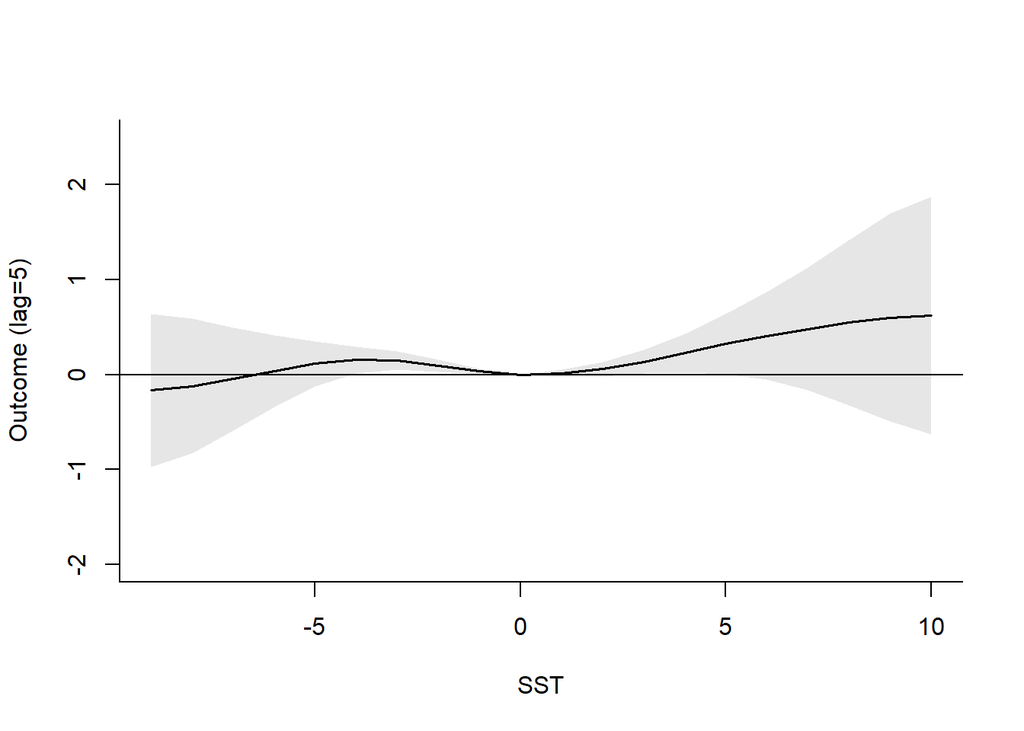

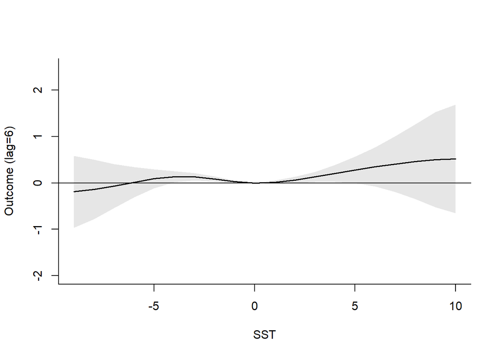

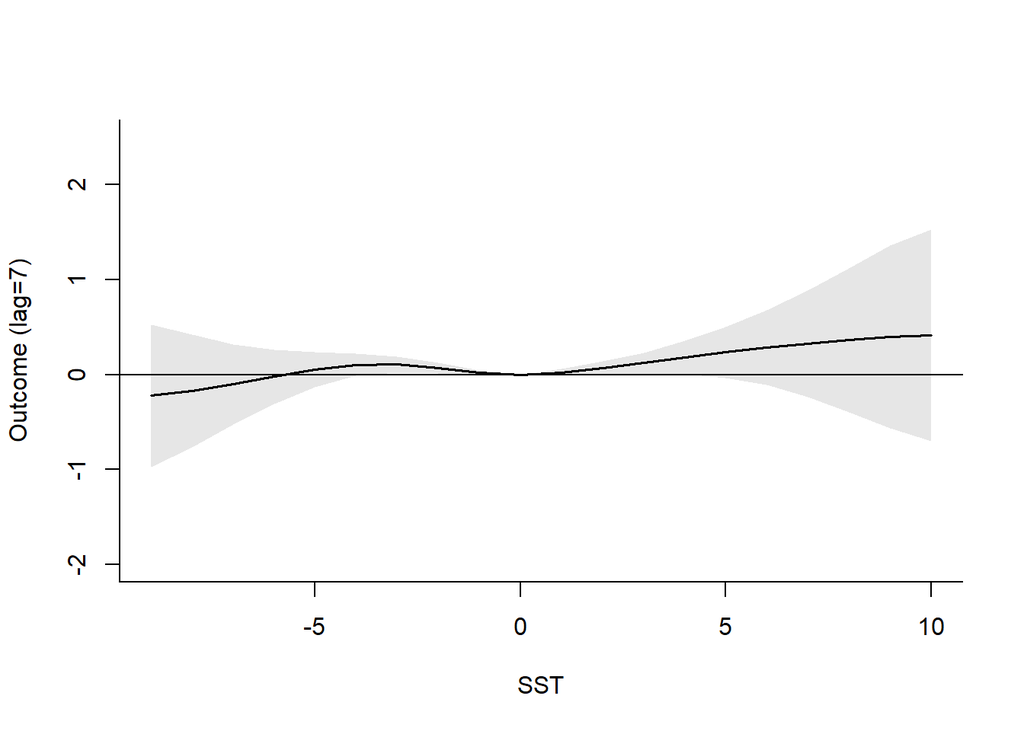

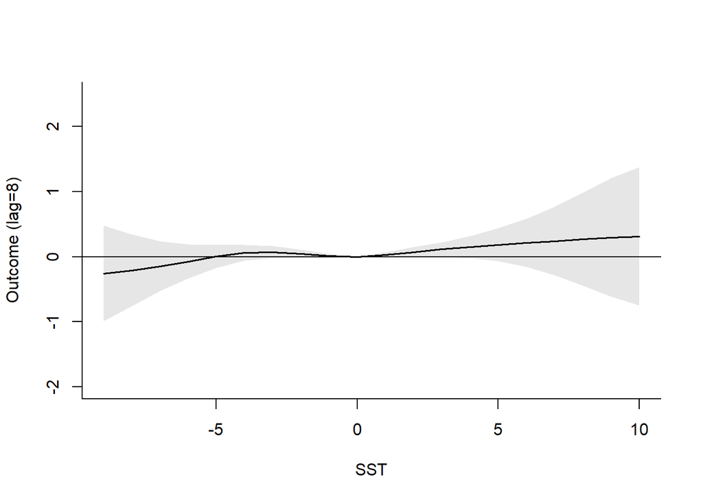

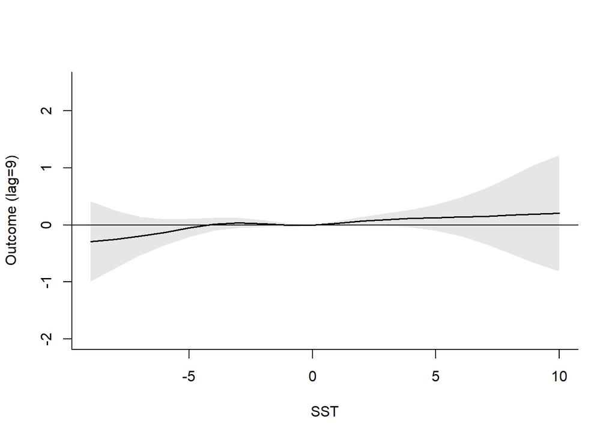

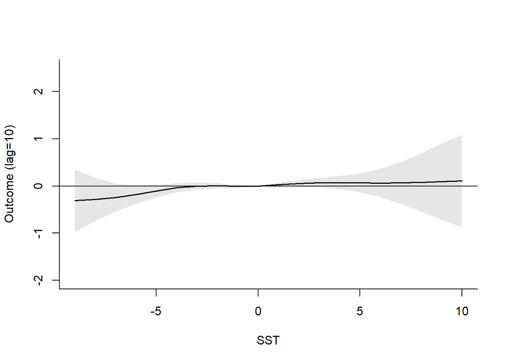

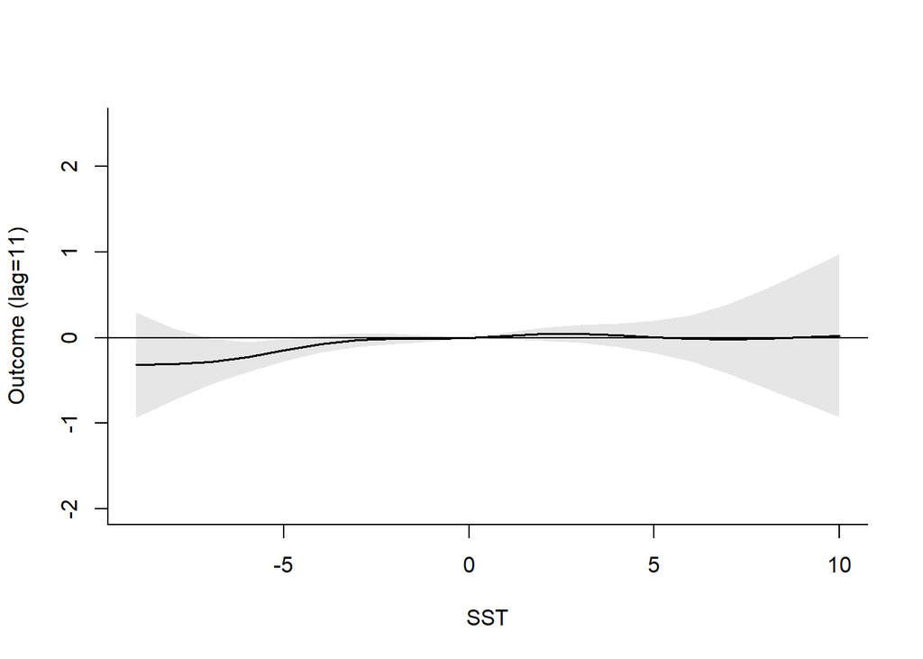

[18 more figures not shown]

```r
pl_func <- function(cross_pred, lag){
  plot(cross_pred, lag = lag, ylab = paste0('Outcome (lag=', lag, ')'),
       xlab = 'SST', lwd = 1.5, main = '', ylim = c(-2, 2.5))
}

invisible(
  lapply(0:29,
         FUN = pl_func, cross_pred = lag_preds)
)
```

Here’s what I’m seeing in the plots: